# Dataset Insights – Restaurant Reviews

The dataset contains 500 customer reviews from 20 restaurants across 10 cities.

- Total reviews: 500
- Restaurants: 20
- Cities: 10
- Ratings range: 1.0 – 5.0
- Reviewer age range: 18 – 65 years

# Observations

- Positive and Negative reviews are balanced.
- Short reviews are emotionally strong; long reviews provide detailed feedback.
- Useful for sentiment analysis and NLP models.

```python
import matplotlib.pyplot as plt
import seaborn as sns
%matplotlib inline
```

```python
# Reviews per restaurant
restaurant_counts = df.groupBy("RestaurantName").count().toPandas()

# Reviews per city
city_counts = df.groupBy("City").count().toPandas()

# Rating stats per restaurant
rating_stats = df.groupBy("RestaurantName").agg(
    min("Rating").alias("Min_Rating"),
    max("Rating").alias("Max_Rating"),
    avg("Rating").alias("Avg_Rating")
).toPandas()
```

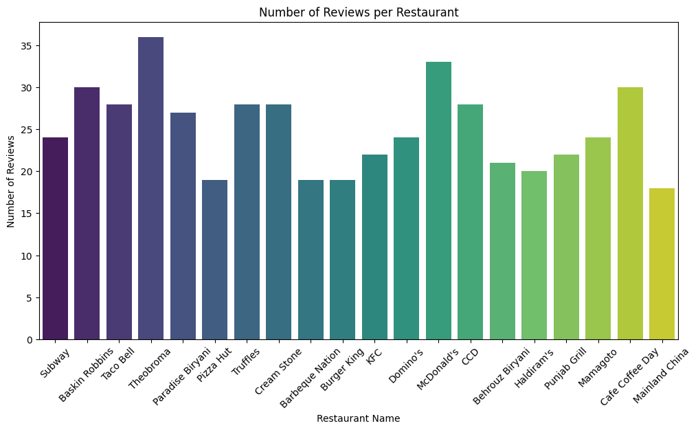

```python
plt.figure(figsize=(12,6))
sns.barplot(x='RestaurantName', y='count', data=restaurant_counts, palette='viridis')
plt.xticks(rotation=45)
plt.title("Number of Reviews per Restaurant")
plt.ylabel("Number of Reviews")
plt.xlabel("Restaurant Name")
plt.show()
```

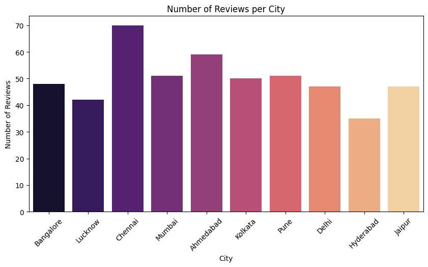

```python
plt.figure(figsize=(10,5))
sns.barplot(x='City', y='count', data=city_counts, palette='magma')
plt.xticks(rotation=45)
plt.title("Number of Reviews per City")
plt.ylabel("Number of Reviews")
plt.xlabel("City")
plt.show()
```

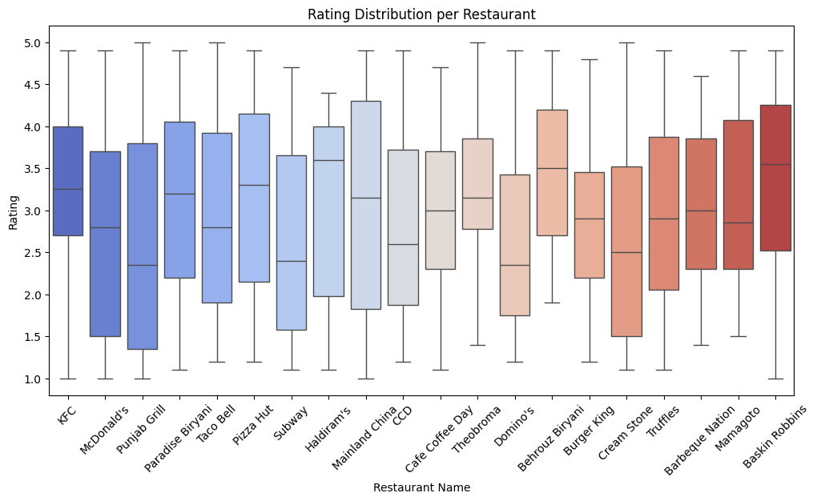

```python
# Collect RestaurantName and Rating for boxplot
ratings_df = df.select("RestaurantName", "Rating").toPandas()

plt.figure(figsize=(12,6))
sns.boxplot(x="RestaurantName", y="Rating", data=ratings_df, palette='coolwarm')
plt.xticks(rotation=45)
plt.title("Rating Distribution per Restaurant")
plt.ylabel("Rating")
plt.xlabel("Restaurant Name")
plt.show()
```

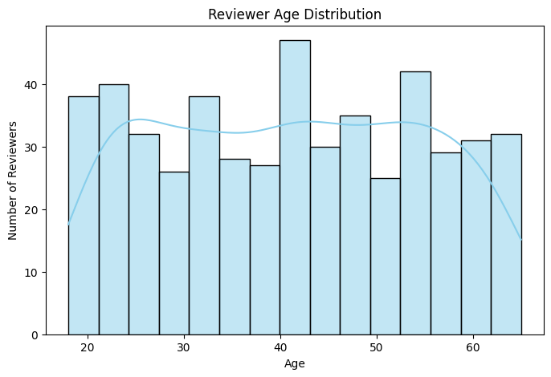

```python
age_df = df.select("ReviewerAge").toPandas()

plt.figure(figsize=(8,5))
sns.histplot(age_df['ReviewerAge'], bins=15, kde=True, color='skyblue')
plt.title("Reviewer Age Distribution")
plt.xlabel("Age")
plt.ylabel("Number of Reviewers")
plt.show()
```

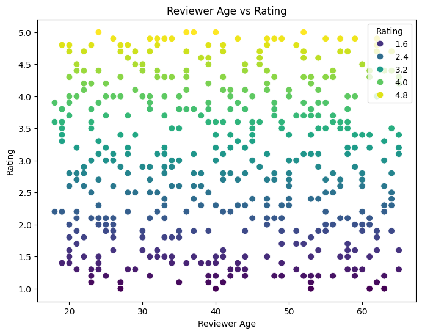

```python
age_rating_df = df.select("ReviewerAge","Rating").toPandas()

plt.figure(figsize=(8,6))
sns.scatterplot(x="ReviewerAge", y="Rating", data=age_rating_df, hue="Rating", palette="viridis", s=60)
plt.title("Reviewer Age vs Rating")
plt.xlabel("Reviewer Age")
plt.ylabel("Rating")
plt.show()
```

# Conclusion – Restaurant Reviews Dataset

The dataset provides insights into customer feedback across *500 reviews* for *20 restaurants* in *10 cities. It reflects a **balanced distribution of sentiments*, with roughly equal numbers of positive and negative reviews, making it ideal for sentiment analysis.

- The *ratings* range from 1 to 5, showing varied customer satisfaction levels across restaurants.
- Reviewers’ ages span from 18 to 65, capturing perspectives from both young and experienced customers.
- Short reviews are often emotionally strong, while longer reviews provide detailed feedback about food, service, and ambiance.
- The dataset is *clean and consistent*, with no missing values, making it suitable for machine learning and NLP applications.

Overall, the dataset is perfect for:

- *Sentiment classification models*
- *Text preprocessing and feature extraction exercises*
- *Analyzing restaurant performance and customer satisfaction trends*

It can be used to build *predictive models, understand **customer preferences*, and derive actionable insights for restaurant operations and marketing strategies.